# Desafío Brain Food

Cristóbal Campora | ci.campora@gmail.com | +569 84231239

3 de diciembre de 2018

El desafío consiste en realizar un modelo con enfoque Machine Learning para obtener las predicciones de consumo de Gas en la Región de Magallanes en un horizonte diario (1-7 días), semanal (1-5 semanas) y mensual (1-3 meses).

Para ello se cuenta con la siguiente base de datos.

| Consumo | Dia | Mes | Año | DiaSemana | Feriado |
| --- | --- | --- | --- | --- | --- |
| 716 | 20 | 10 | 1995 | Viernes | 0 |
| 605 | 21 | 10 | 1995 | Sábado | 1 |
| 555 | 22 | 10 | 1995 | Domingo | 1 |
| 680 | 23 | 10 | 1995 | Lunes | 0 |
| 713 | 24 | 10 | 1995 | Martes | 0 |
| 710 | 25 | 10 | 1995 | Miércoles | 0 |

La Base muestra el consumo diario de Gas en la región de Magallanes desde el 20 Octubre de 1995 al 31 de Diciembre de 2002. Con las columnas Año, Mes y Día se construyó la nueva columna “date”.

A continuación un resumen de la base.

```
##     Consumo            Dia            Mes            Año
##  Min.   : 333.0   20     :  87   12     : 248   1996   :366
##  1st Qu.: 579.0   21     :  87   11     : 240   2000   :366
##  Median : 715.0   22     :  87   10     : 229   1997   :365
##  Mean   : 725.6   23     :  87   1      : 217   1998   :365
##  3rd Qu.: 876.0   24     :  87   3      : 217   1999   :365
##  Max.   :1222.0   25     :  87   5      : 217   2001   :365
##                   (Other):2108   (Other):1262   (Other):438
##      DiaSemana   Feriado       date
##  Domingo  :376   0:2109   Min.   :1995-10-20
##  Jueves   :375   1: 521   1st Qu.:1997-08-07
##  Lunes    :376            Median :1999-05-26
##  Martes   :376            Mean   :1999-05-26
##  Miércoles:375            3rd Qu.:2001-03-13
##  Sábado   :376            Max.   :2002-12-31
##  Viernes  :376
```

# Construcción de las bases

Antes de empezar a modelar los datos debemos formar dos nuevas bases (semanal y mensual) por lo que debemos agregar los valores darios a base semanal y mensual. Para esto utilizamos el paquete xts que permite aplicar funciones por periodo de tiempo de manera mas simple.

Convertimos la base en formato serie de tiempo con la funcion xts.

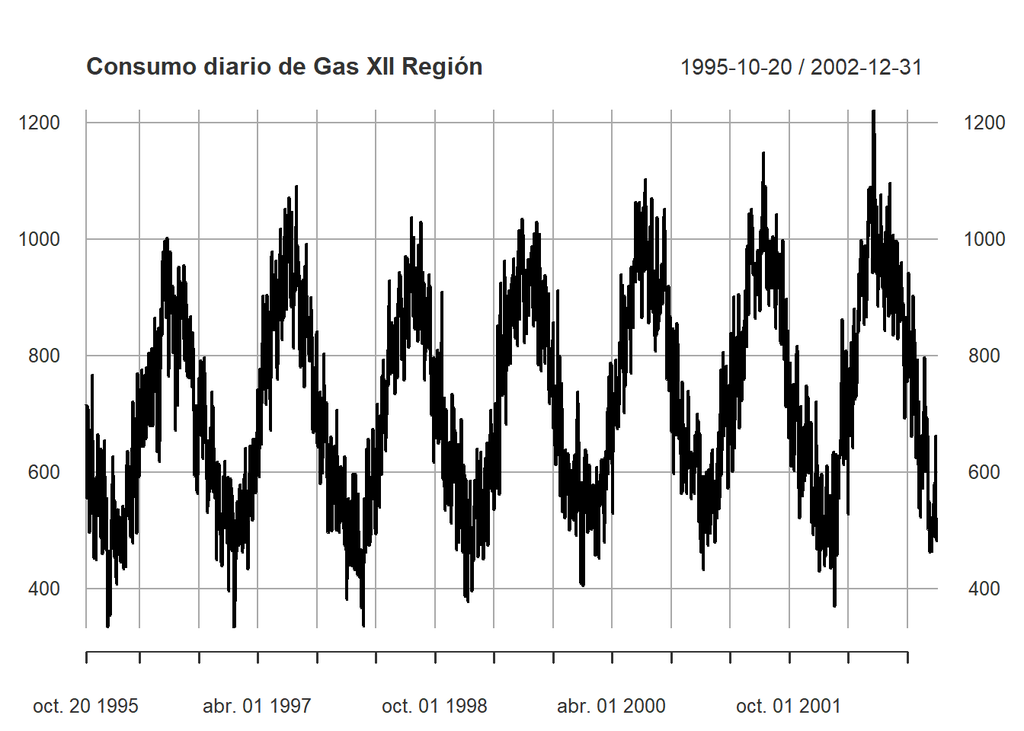

```r
bf.ts <- xts(bf$Consumo,bf$date)
plot.xts(bf.ts, main="Consumo diario de Gas XII Región")
```

Para la base semanal tomaremos semanas completas de Lunes a Domingo y sumamos los consumos

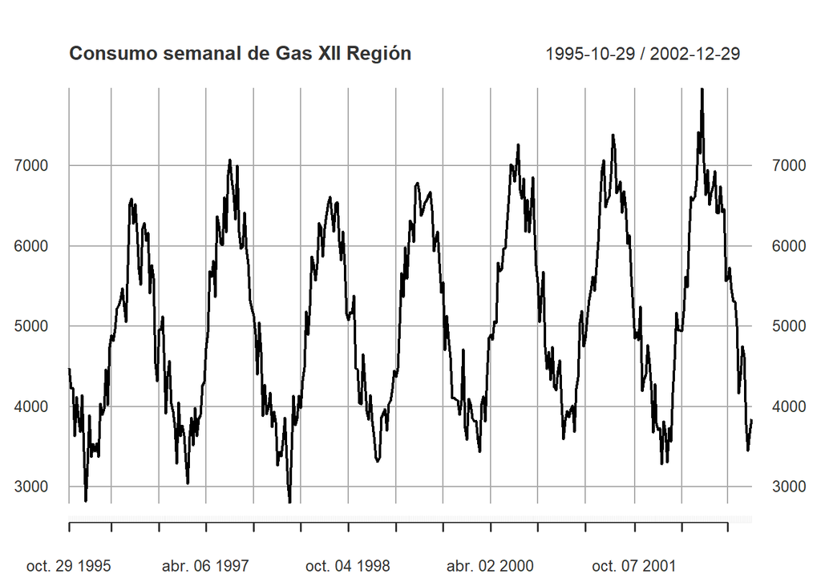

```r
bf_weekly <- bf.ts %>% apply.weekly(FUN=sum) %>% window(start=as.Date("1995-10-29"),end=as.Date("2002-12-29"))
base_sem <- data.frame(coredata(bf_weekly),week(index(bf_weekly)),year(bf_weekly),month(bf_weekly),seq(1,nrow(bf_weekly)))
colnames(base_sem) <- c("Consumo","Semana","Año","Mes","index")
base_sem$Semana <- as.factor(base_sem$Semana)
base_sem$Mes <- as.factor(base_sem$Mes)
plot.xts(bf_weekly, main="Consumo semanal de Gas XII Región")
```

Para la base mensual haremos lo mismo, tomando meses completos

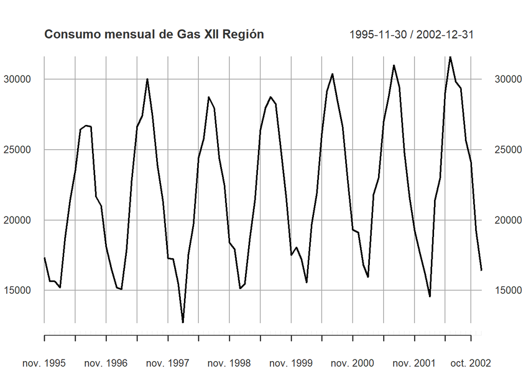

```r
bf_monthly <- bf.ts %>% apply.monthly(FUN=sum) %>% window(start=as.Date("1995-11-30"),end=as.Date("2002-12-31"))
base_mes <- data.frame(coredata(bf_monthly),month(index(bf_monthly)),year(bf_monthly),seq((1995+10/12),(2002+11/12),by=1/12))
colnames(base_mes) <- c("Consumo","Mes","Año","index")
base_mes$Mes <- as.factor(base_mes$Mes)
plot.xts(bf_monthly, main="Consumo mensual de Gas XII Región")
```

# Modelo Mensual

## Ajuste del modelo

Ajustaremos un modelo de regresión lineal a la base mensual con el objetivo de extraer sus componentes de estacionalidad y tendencia. Luego analizaremos los residuos y ajustaremos un modelo ARIMA a éstos.

La predicción final será entonces la suma de la predicción de regresión lineal mas la predicción del error por el modelo ARIMA ajustado.

Para entrenar el modelo utilizaremos toda la base menos los 3 últimos meses que utilizaremos como test set.

```r
train_mes <- seq(1,83)
test_mes <- seq(84,86)
# Regresión lineal simple que de cuenta de tendencia y estacionalidad
mod1_m <- lm(Consumo ~ index+Mes, data=base_mes[train_mes,])
```

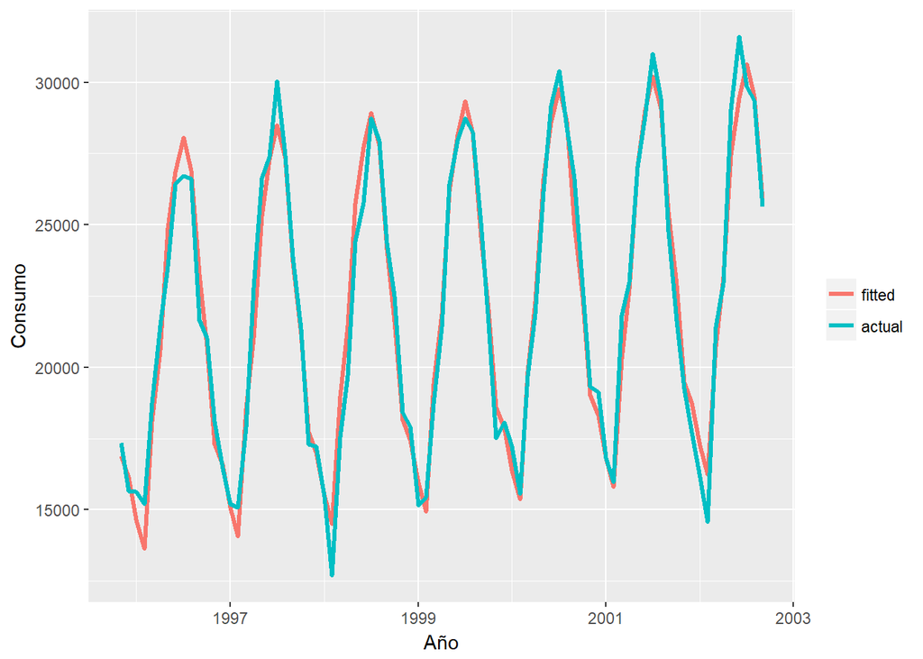

```
##
## Call:
## lm(formula = Consumo ~ index + Mes, data = base_mes[train_mes,
##     ])
##
## Residuals:
##      Min       1Q   Median       3Q      Max
## -1951.49  -464.47    92.31   509.14  2135.18
##
## Coefficients:
##               Estimate Std. Error t value Pr(>|t|)
## (Intercept) -847785.10  106171.49  -7.985 1.95e-11 ***
## index           432.08      53.11   8.135 1.03e-11 ***
## Mes2          -1052.29     512.21  -2.054  0.04367 *
## Mes3           3391.27     512.27   6.620 6.11e-09 ***
## Mes4           5829.84     512.37  11.378  < 2e-16 ***
## Mes5          10085.40     512.50  19.679  < 2e-16 ***
## Mes6          12038.82     512.67  23.483  < 2e-16 ***
## Mes7          13189.10     512.88  25.716  < 2e-16 ***
## Mes8          12014.09     513.13  23.413  < 2e-16 ***
## Mes9           8333.52     513.42  16.232  < 2e-16 ***
## Mes10          5761.60     533.27  10.804  < 2e-16 ***
## Mes11          2298.30     512.27   4.487 2.77e-05 ***
## Mes12          1535.29     512.21   2.997  0.00377 **
## ---
## Signif. codes:  0 '***' 0.001 '**' 0.01 '*' 0.05 '.' 0.1 ' ' 1
##
## Residual standard error: 958.2 on 70 degrees of freedom
## Multiple R-squared:  0.9695, Adjusted R-squared:  0.9643
## F-statistic: 185.4 on 12 and 70 DF,  p-value: < 2.2e-16
```

El modelo entrega un R2 de 0.96 indicativo de que gran parte de la varianza se explica con las variables “index” y “Mes”. Una vez ajustado el modelo nos fijamos en los residuos, los cuales ajustaremos a un modelo ARIMA.

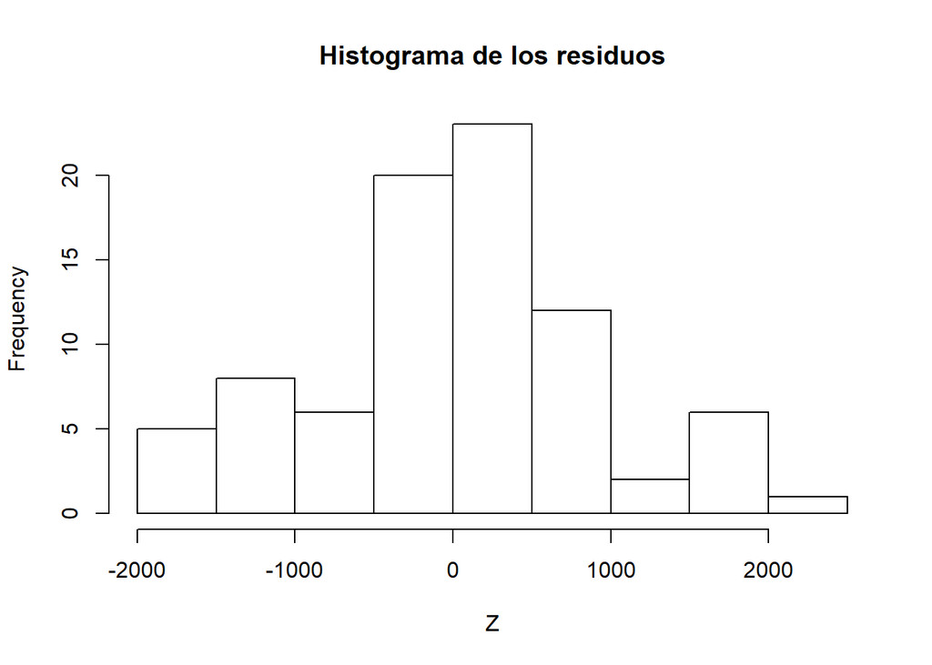

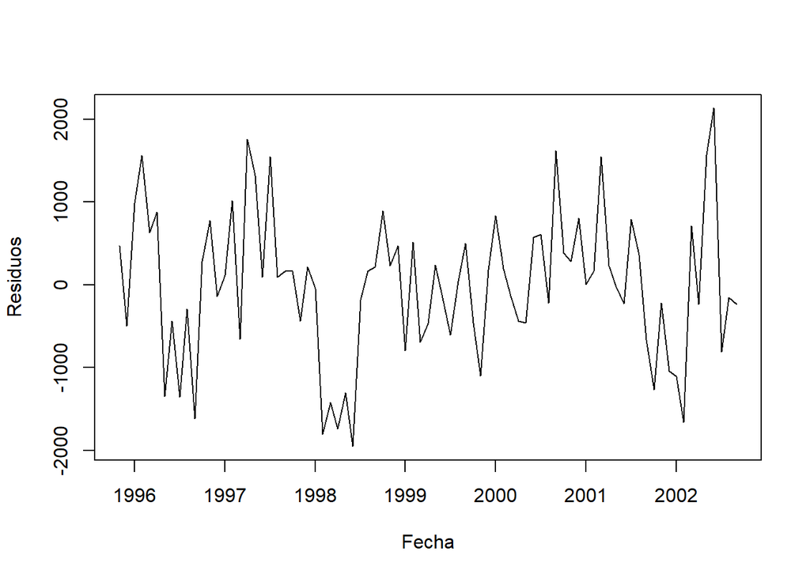

Para ajustar los residuos a un modelo ARIMA debemos chequear si son estacionarios o no. Para ello utilizamos el test ADF el cual plantea como hipótesis alternativa la estacionaridad.

```r
adf.test(Z, k=0)
```

```
##
##  Augmented Dickey-Fuller Test
##
## data:  Z
## Dickey-Fuller = -6.4731, Lag order = 0, p-value = 0.01
## alternative hypothesis: stationary
```

Obervamos que el p-value es menor a 0.05 por lo que rechazamos la hipótesis nula y aceptamos la hipótesis alternativa. Los residuos son estacionarios.

Ahora, nos fijamos en si existen correlación entre los residuos con la función ts.diag (del paquete LSTS) y con el test de Ljung-Box

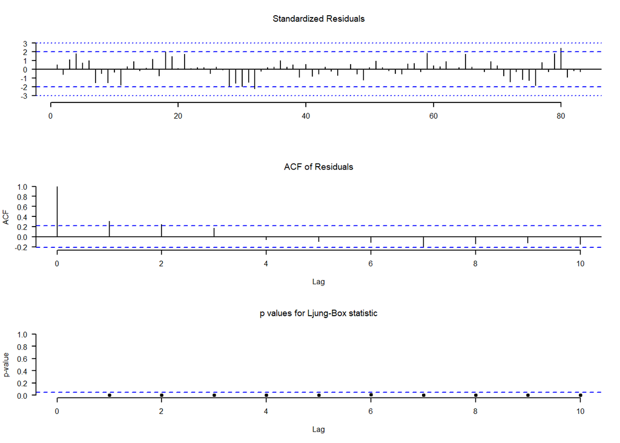

```r
# Dependencia serial empírica de los residuos
ts.diag(Z)
```

```r
# Test de Ljung-Box
Box.test(Z, type="Ljung-Box")
```

```
##
##  Box-Ljung test
##
## data:  Z
## X-squared = 8.1608, df = 1, p-value = 0.004281
```

El p-value es menor a 0.05 por lo tanto se rechaza la hipotesis de independencia por lo que podemos decir que existen correlaciones en los residuos.

Graficamos el ACF y PACF en busqueda de los coeficientes p y q del modelo ARIMA

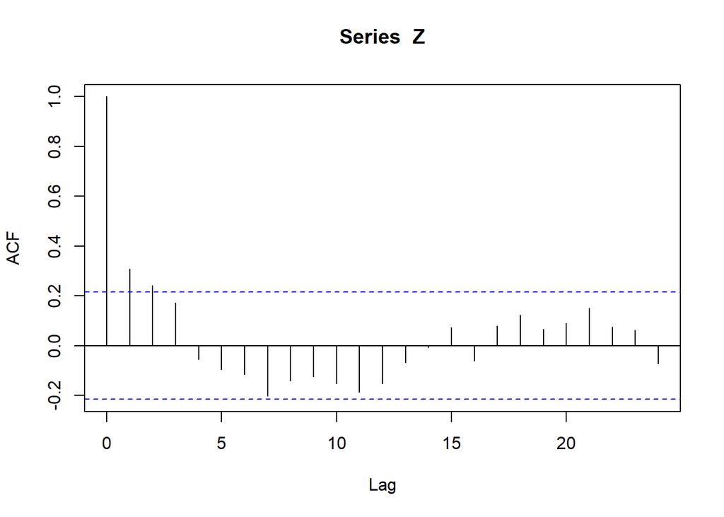

```r
acf(Z, lag.max = 24)
```

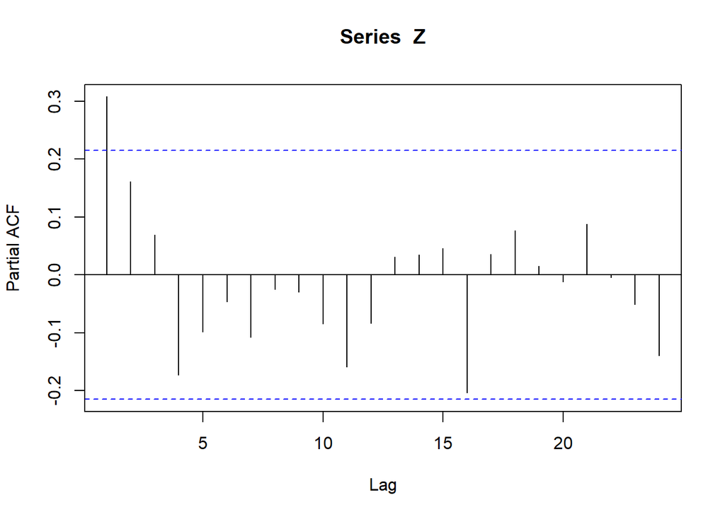

```r
pacf(Z, lag.max = 24)
```

El gráfico sugiere un modelo arima (1,0,2) sin embargo probaremos mas modelos con un loop “for” con p y q de 0 a 4 y además con la función auto.arima que automaticamente busca el mejor modelo. Como criterio de bondad de los modelos se guardaron en una matriz los valores del AIC, los cuales se muestran a continuación.

```
## Series: Z
## ARIMA(2,0,2) with zero mean
##
## Coefficients:
##          ar1      ar2      ma1     ma2
##       1.1064  -0.7466  -0.9836  0.8979
## s.e.  0.1022   0.1178   0.0735  0.1004
##
## sigma^2 estimated as 663286:  log likelihood=-672.71
## AIC=1355.42   AICc=1356.2   BIC=1367.51
```

Matriz de valores de AIC (filas: valores de p, columnas: valores de q)

|  | 0 | 1 | 2 | 3 | 4 |
| --- | --- | --- | --- | --- | --- |
| 0 | 1365.009 | 1360.860 | 1360.358 | 1358.095 | 1359.952 |
| 1 | 1358.799 | 1359.054 | 1359.910 | 1359.974 | 1361.782 |
| 2 | 1358.677 | 1360.555 | 1357.409 | 1357.980 | 1360.703 |
| 3 | 1360.263 | 1357.462 | 1357.873 | 1359.759 | 1361.758 |
| 4 | 1359.270 | 1357.147 | 1359.785 | 1361.808 | 1360.109 |

La función auto.arima entrega un modelo (2,0,2). La matriz entrega valores mínimos de AIC en los modelos (3,0,1) y (4,0,1) y al igual que auto.arima en (2,0,2). El siguiente paso es remover los coeficientes no significativos de cada modelo observando si el intervalo de confienza contiene el 0. Los resultados de los valores de AIC para los cuatro modelos se muestran a continuación.

AIC después de remover coeficientes no significativos

[output not shown]

## Forecast Modelo Mensual

Una vez que hemos obtenido los modelos con los menores valores de AIC, hacemos el forecast para 3 meses.

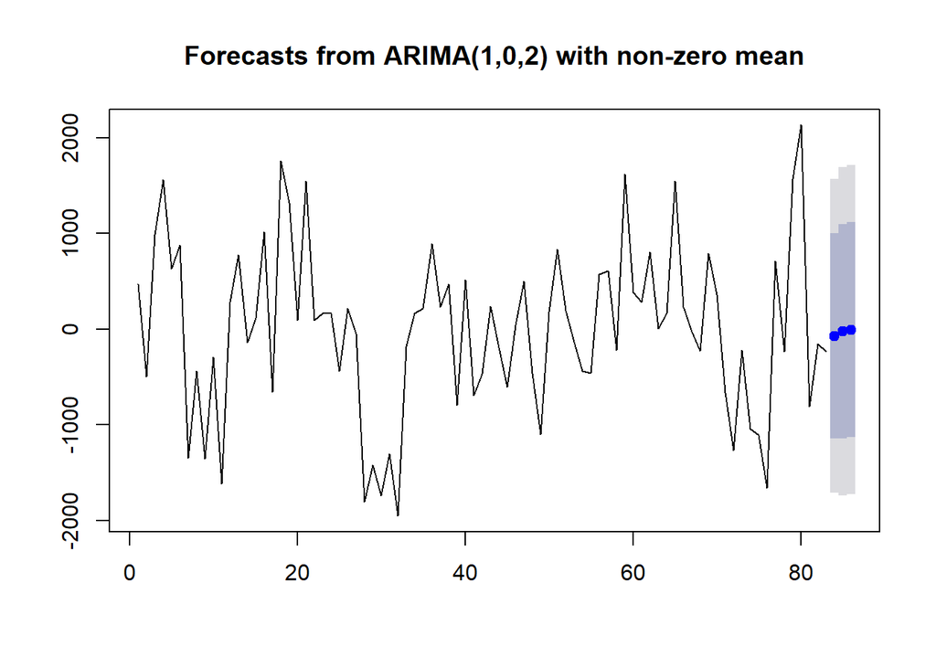

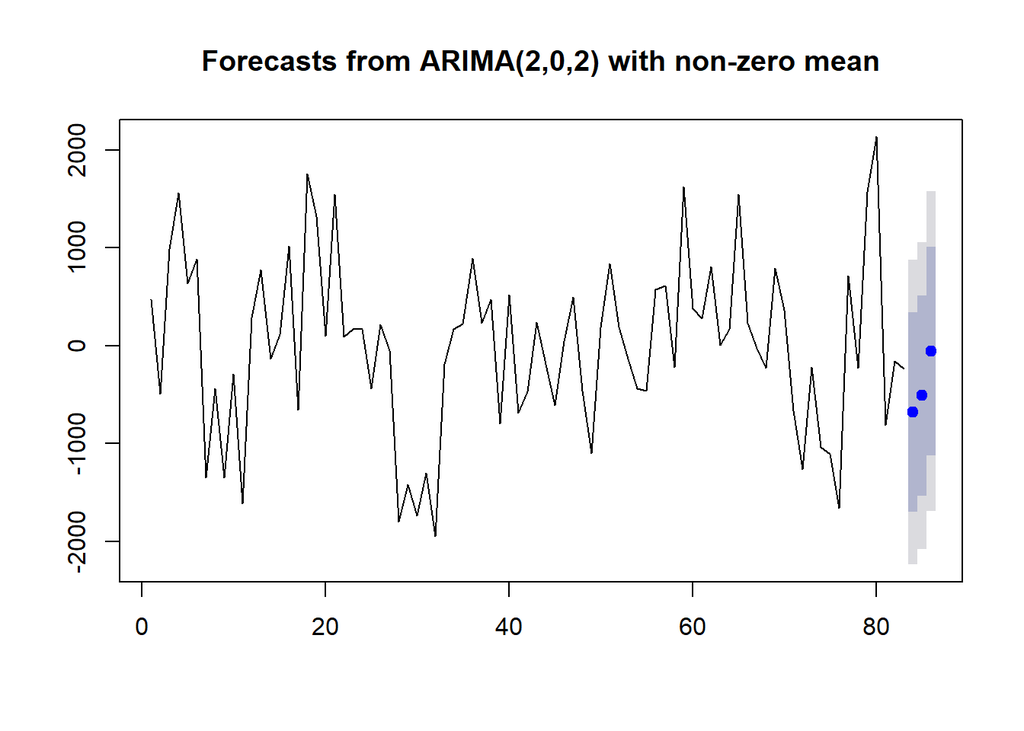

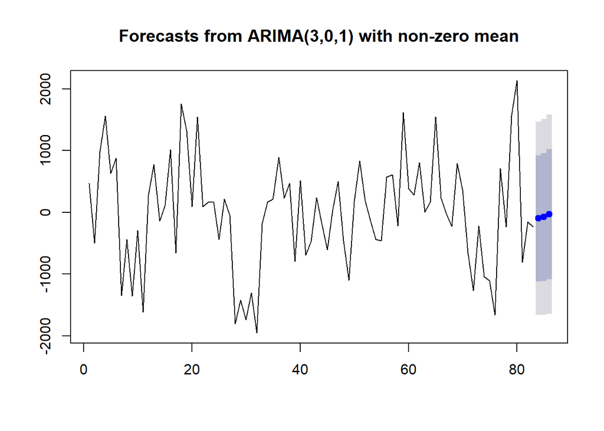

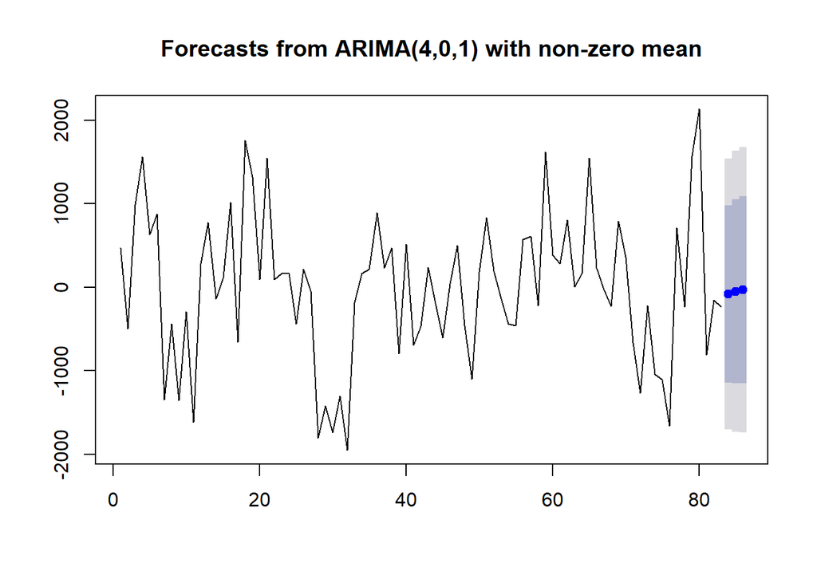

Las predicción total es la predicción del modelo lineal + modelo arima

```r
pred_arima1 <- predict(mod1_m, newdata=base_mes[test_mes,])+fcast_arima1$mean
pred_arima2 <- predict(mod1_m, newdata=base_mes[test_mes,])+fcast_arima2$mean
pred_arima3 <- predict(mod1_m, newdata=base_mes[test_mes,])+fcast_arima3$mean
pred_arima4 <- predict(mod1_m, newdata=base_mes[test_mes,])+fcast_arima4$mean
```

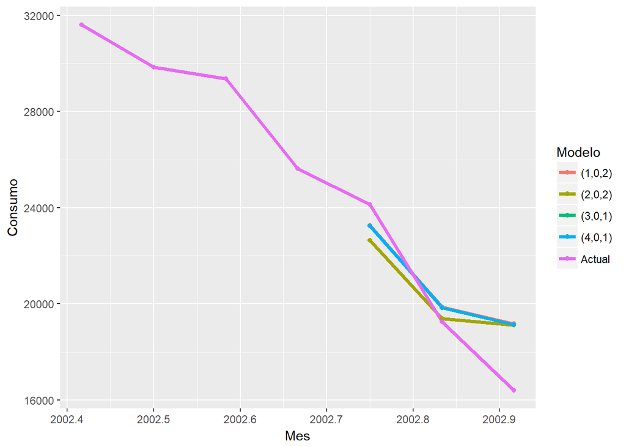

## RMSE y Error porcentual Modelo Mensual

Con el objetivo de evaluar la performance de nuestros modelos computamos el RMSE (root mean square error) y el error porcentual de la siguiente manera.

```r
rmse1 <- sqrt(mean((base_mes$Consumo[test_mes]-pred_arima1)^2))
erp1 <- mean(abs(base_mes$Consumo[test_mes]-pred_arima1)/base_mes$Consumo[test_mes])*100
```

Lo que da como resultado la siguiente tabla resumen en donde se incorporan también los valores de AIC

Tabla resumen modelo mensual

[output not shown]

Como se observa en la tabla, el RMSE menor corresponde al modelo ARIMA (3,0,1) el cual entrega las siguientes predicciones:

Valores reales y predichos de Consumo de Gas

|  | Mes | Consumo real | Predicción |
| --- | --- | --- | --- |
| 84 | Octubre 2002 | 24129 | 23232.64 |
| 85 | Noviembre 2002 | 19250 | 19827.56 |
| 86 | Diciembre 2002 | 16410 | 19146.07 |

# Modelo Semanal

## Ajuste del modelo

Del mismo modo anterior, ajustaremos un modelo lineal que de cuenta de tendencia y estacionalidad de la serie. Para entrenar el modelo usaremos toda la base menos las últimas 5 semanas, que utilizaremos como test set.

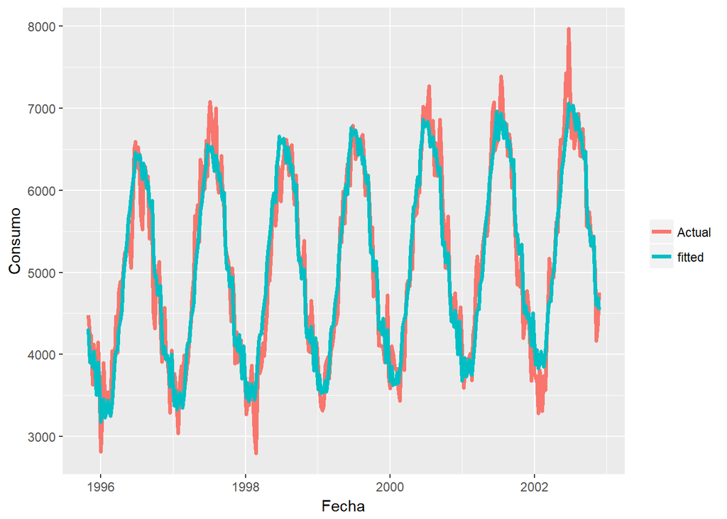

```
##
## Call:
## lm(formula = Consumo ~ index + Semana + Mes, data = base_sem[train_sem,
##     ])
##
## Residuals:
##     Min      1Q  Median      3Q     Max
## -854.84 -204.56    8.99  208.76  906.18
##
## Coefficients: (1 not defined because of singularities)
##              Estimate Std. Error t value Pr(>|t|)
## (Intercept) 3255.8153   125.5377  25.935  < 2e-16 ***
## index          1.9131     0.1602  11.945  < 2e-16 ***
## Semana2      174.6583   173.4467   1.007 0.314737
## Semana3      -51.1120   173.4469  -0.295 0.768435
## Semana4       -8.0252   173.4473  -0.046 0.963126
## Semana5      -42.7049   260.2135  -0.164 0.869749
## Semana6     -100.4390   322.2298  -0.312 0.755481
## Semana7     -232.2092   322.2331  -0.721 0.471690
## Semana8      -67.9795   322.2365  -0.211 0.833058
## Semana9       35.2693   376.1891   0.094 0.925366
## Semana10     354.0781   421.5001   0.840 0.401540
## Semana11     444.4507   421.5051   1.054 0.292515
## Semana12     452.3947   421.5101   1.073 0.283995
## Semana13     709.5609   424.3992   1.672 0.095563 .
## Semana14     756.2671   548.0615   1.380 0.168626
## Semana15     894.6397   548.0598   1.632 0.103629
## Semana16    1237.1551   548.0581   2.257 0.024691 *
## Semana17    1454.5277   548.0565   2.654 0.008371 **
## Semana18    1738.3919   624.9768   2.782 0.005746 **
## Semana19    1938.8702   650.5369   2.980 0.003109 **
## Semana20    2174.9571   650.5381   3.343 0.000931 ***
## Semana21    2288.9011   650.5392   3.518 0.000500 ***
## Semana22    2177.2964   665.7764   3.270 0.001197 **
## Semana23    2342.8290   696.1499   3.365 0.000862 ***
## Semana24    2496.3444   696.1510   3.586 0.000391 ***
## Semana25    2719.7170   696.1523   3.907 0.000115 ***
## Semana26    2635.5261   697.9352   3.776 0.000191 ***
## Semana27    2908.9466   779.5080   3.732 0.000227 ***
## Semana28    2948.8906   779.5052   3.783 0.000186 ***
```

[output cut: 27 more lines]

```
## Mes4         346.2905   519.9200   0.666 0.505884
## Mes5         162.5503   626.9744   0.259 0.795608
## Mes6         418.5104   674.1792   0.621 0.535213
## Mes7         156.4545   760.0538   0.206 0.837048
## Mes8         286.8809   836.8207   0.343 0.731967
## Mes9         233.5413   872.8977   0.268 0.789228
## Mes10        385.8008   360.5875   1.070 0.285497
## Mes11        148.2777   271.5520   0.546 0.585438
## Mes12              NA         NA      NA       NA
## ---
## Signif. codes:  0 '***' 0.001 '**' 0.01 '*' 0.05 '.' 0.1 ' ' 1
##
## Residual standard error: 324.5 on 306 degrees of freedom
## Multiple R-squared:  0.934,  Adjusted R-squared:  0.9204
## F-statistic:  68.7 on 63 and 306 DF,  p-value: < 2.2e-16
```

El R2 es 0.93 lo que significa que 93% de la varianza está explicada por las variables introducidas en el modelo. Una vez ajustado el modelo nos fijamos en los residuos, los cuales ajustaremos a un modelo ARIMA.

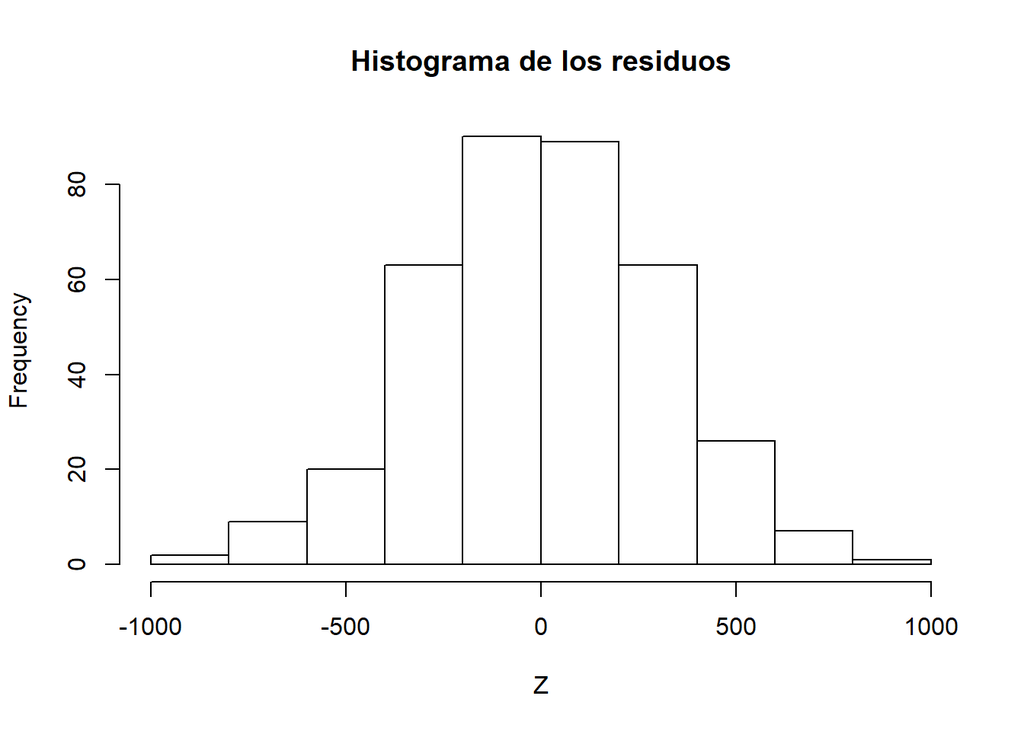

```r
Z <- mod3_s$res
# Observamos que los residuos tienen una distribución normal
hist(Z, main="Histograma de los residuos")
```

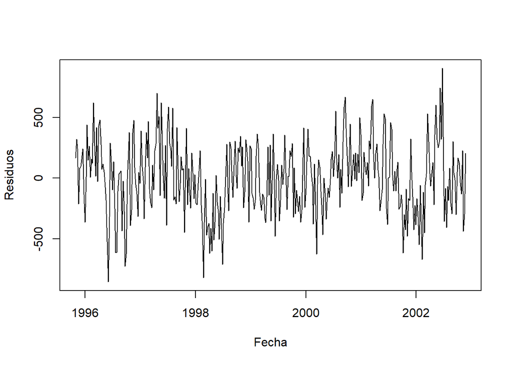

```r
plot(index(bf_weekly)[train_sem],Z, xlab="Fecha", ylab="Residuos",type="l")
```

Observamos si los residuos son estacionarios con el test ADF.

```r
adf.test(Z, k=0)
```

```
##
##  Augmented Dickey-Fuller Test
##
## data:  Z
## Dickey-Fuller = -11.926, Lag order = 0, p-value = 0.01
## alternative hypothesis: stationary
```

El p-value es menor a 0.05 por lo que concluimos que los residuos son estacionarios. Ahora observamos si los residuos estan autocorrelacionados.

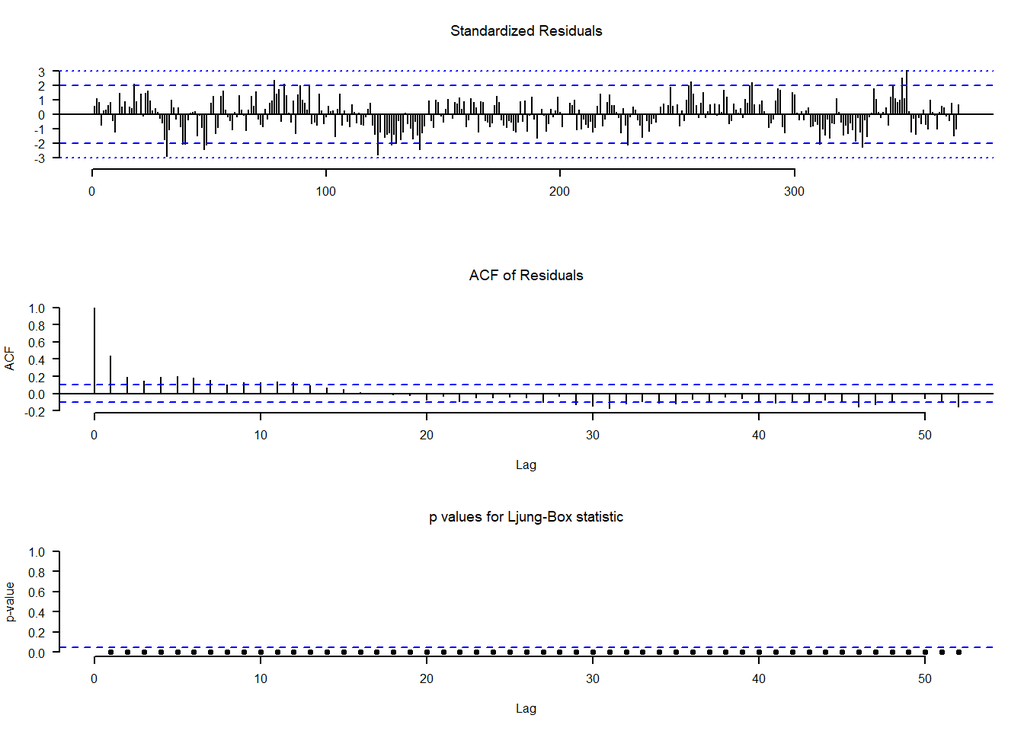

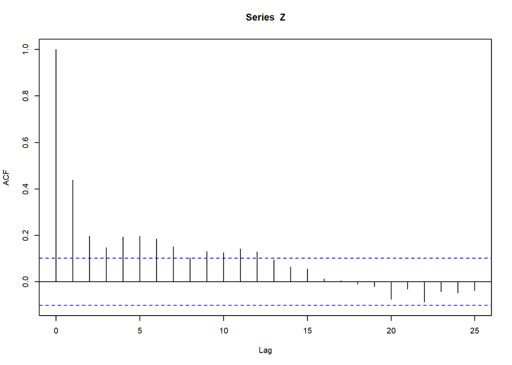

Observamos que existe cierta correlación entre los residuos, por lo que aplicamos la función diff() para obtener una nueva serie no autocorrelacionada para ajustar un modelo ARIMA.

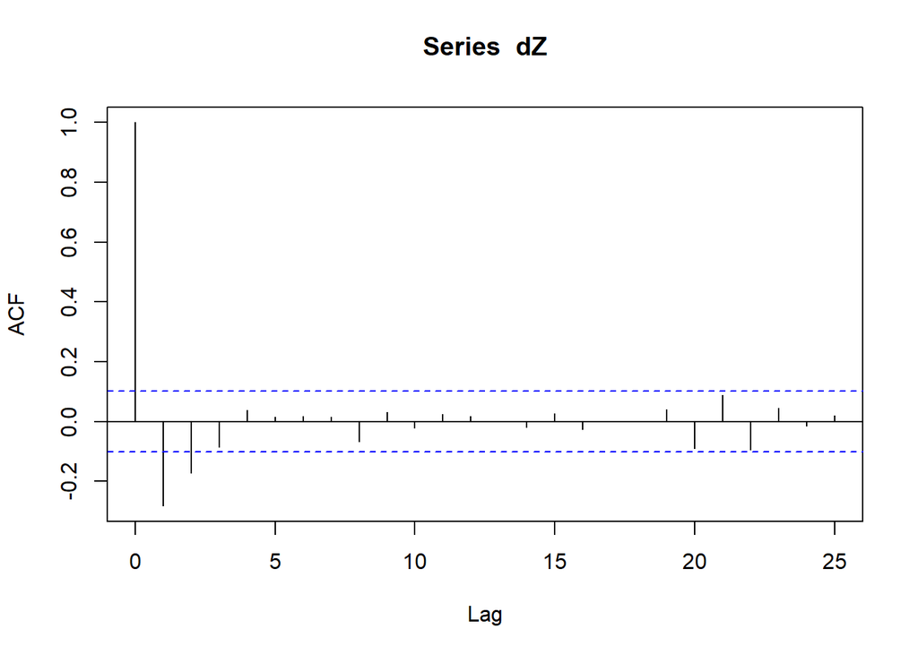

Ahora, simularemos modelos ARIMA (p,1,q) para p y q entre 0 y 4 y guardaremos en una matriz sus valores de AIC.

Matriz de valores de AIC (filas: valores de p, columnas: valores de q)

|  | 0 | 1 | 2 | 3 | 4 |
| --- | --- | --- | --- | --- | --- |
| 0 | 5288.827 | 5199.739 | 5174.290 | 5175.612 | 5176.251 |
| 1 | 5260.110 | 5175.842 | 5175.842 | 5176.916 | 5178.249 |
| 2 | 5233.066 | 5175.121 | 5176.873 | 5178.306 | 5180.236 |
| 3 | 5208.449 | 5176.604 | 5178.324 | 5180.232 | 5181.406 |
| 4 | 5199.182 | 5178.066 | 5171.361 | 5173.332 | 5178.613 |

La matriz nos entrega los modelos (4,1,2),(2,1,1),(0,1,3),(1,1,2)

```r
autoarima <- auto.arima(Z)
autoarima
```

```
## Series: Z
## ARIMA(1,0,2) with zero mean
##
## Coefficients:
##          ar1      ma1      ma2
##       0.9095  -0.5052  -0.2334
## s.e.  0.0439   0.0678   0.0527
##
## sigma^2 estimated as 68938:  log likelihood=-2584.74
## AIC=5177.48   AICc=5177.59   BIC=5193.14
```

La función auto.arima nos entrega el modelo (1,0,2)

Seleccionamos los modelos (4,1,2),(2,1,1),(0,1,3),(1,1,2),(1,0,2), removemos los coeficiente no significativos y obtenemos la siguiente tabla.

| Modelo | AIC |
| --- | --- |
| (4,1,2) | 5176.873 |
| (2,1,1) | 5175.842 |
| (0,1,3) | 5174.290 |
| (1,1,2) | 5199.739 |
| (1,0,2) | 5177.483 |

## Forecast Modelo Semanal

Haremos las predicciones para los modelos (4,1,2), (2,1,1), (0,1,3), (1,1,2) y (1,0,2)

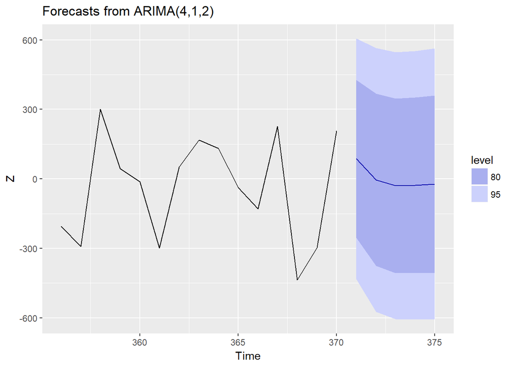

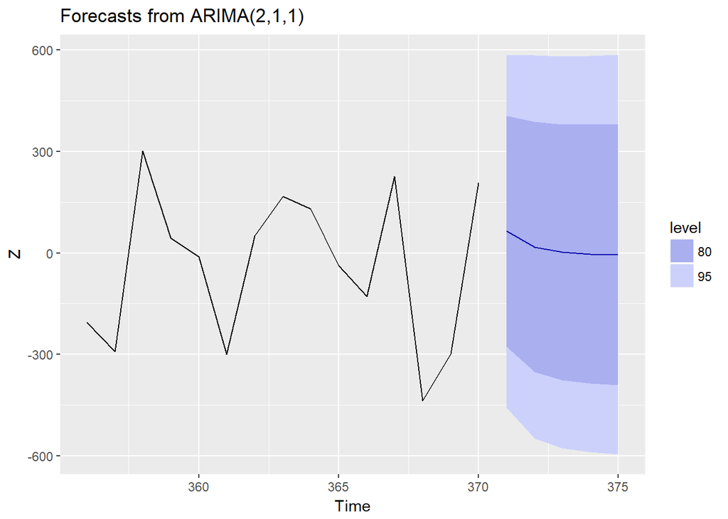

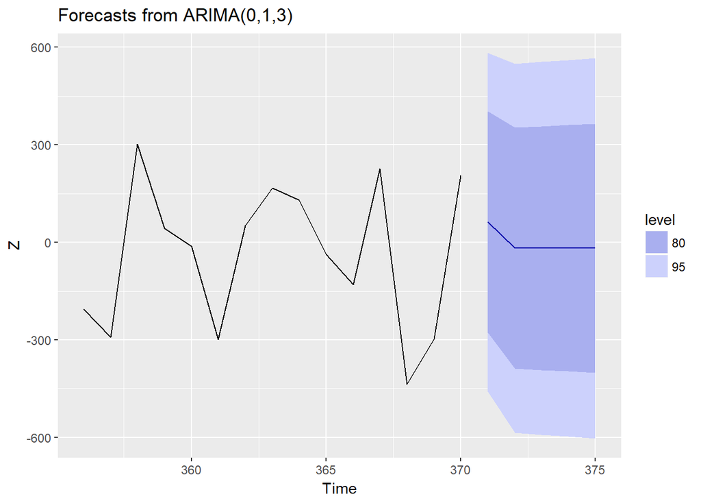

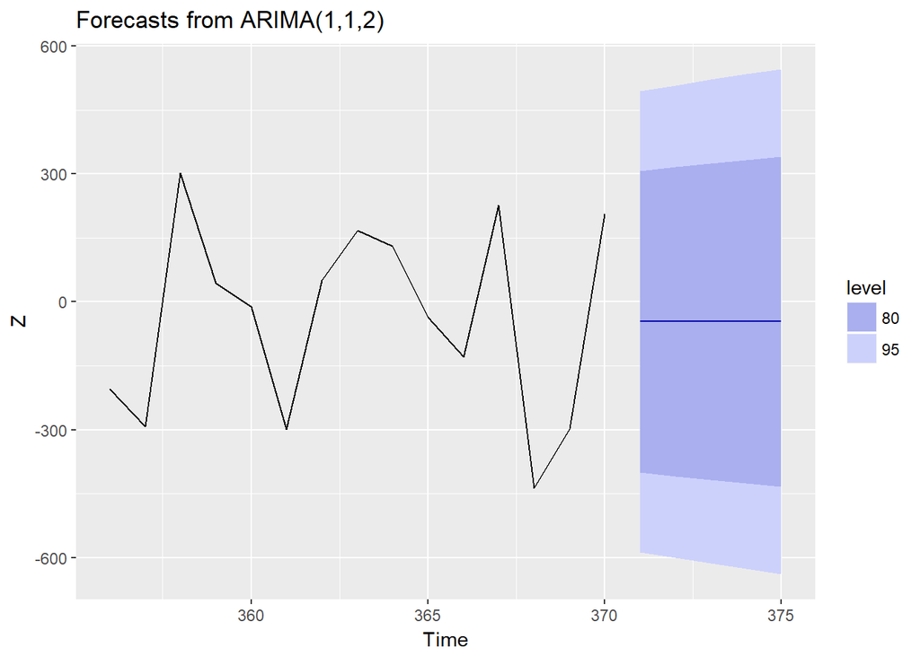

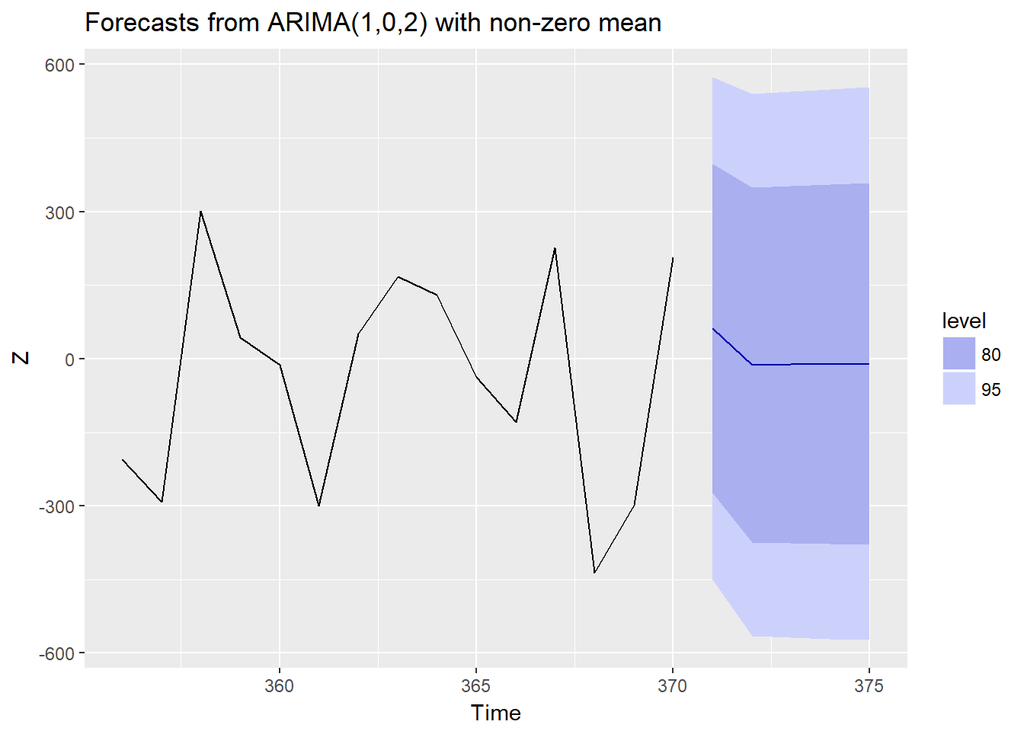

Las predicción final es la predicción del modelo lineal mas modelo ARIMA.

```r
pred_fit <- predict(mod3_s, newdata=base_sem[test_sem,])
pred_arima1 <- pred_fit+fcast_arima1$mean
pred_arima2 <- pred_fit+fcast_arima2$mean
pred_arima3 <- pred_fit+fcast_arima3$mean
pred_arima4 <- pred_fit+fcast_arima4$mean
pred_arima5 <- pred_fit+fcast_arima5$mean
```

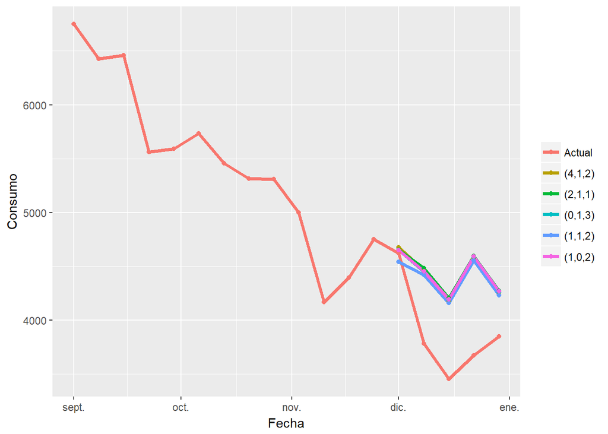

## RMSE y Error porcentual Modelo Semanal

| Modelo | AIC | RMSE | Error % |
| --- | --- | --- | --- |
| (4,1,2) | 5176.873 | 626.9999 | 15.02943 |
| (2,1,1) | 5175.842 | 647.7482 | 15.44830 |
| (0,1,3) | 5174.290 | 629.5348 | 14.98944 |
| (1,1,2) | 5199.739 | 606.0906 | 14.59494 |
| (1,0,2) | 5177.483 | 635.5093 | 15.14031 |

El modelo seleccionado entrega las siguientes predicciones

```r
tabla3 <- data.frame(index(bf_weekly)[test_sem],base_sem$Consumo[test_sem],pred_arima4)
colnames(tabla3) <- c("Fecha","Consumo real","Predicción")
kable(tabla3, align = "c")
```

|  | Fecha | Consumo real | Predicción |
| --- | --- | --- | --- |
| 371 | 2002-12-01 | 4623 | 4543.239 |
| 372 | 2002-12-08 | 3780 | 4419.723 |
| 373 | 2002-12-15 | 3455 | 4159.580 |
| 374 | 2002-12-22 | 3672 | 4555.151 |
| 375 | 2002-12-29 | 3850 | 4230.437 |

# Modelo Diario

## Ajuste del modelo

Ajustaremos un modelo lineal que de cuenta de la tendencia y estacionalidad en la serie diaria. Para entrenar el modelo usaremos toda la base menos los 7 últimos días los cuales utilizaremos como test set.

```r
bf$index <- seq(1,2630)
train_d <- seq(1,2623)
test_d <- seq(2624,2630)
mod4_d <- lm(Consumo ~ index+Mes+DiaSemana+Feriado, data=bf[train_d,])
```

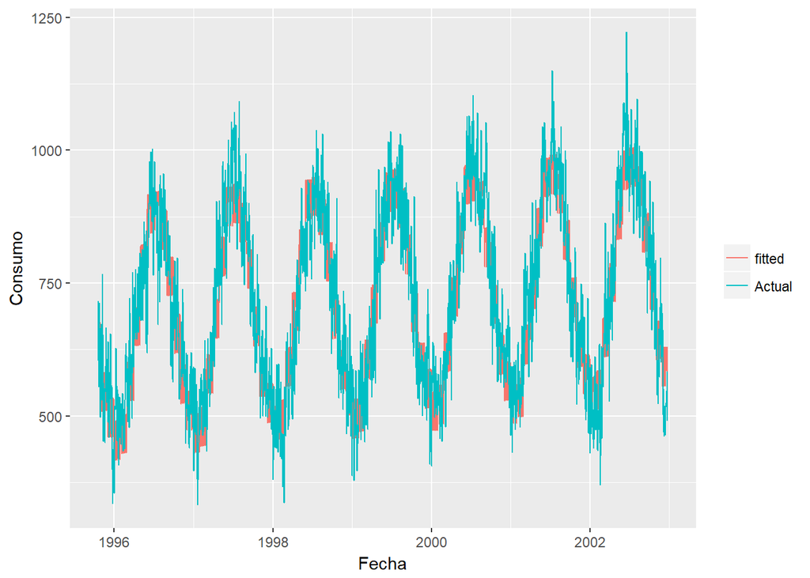

```
##
## Call:
## lm(formula = Consumo ~ index + Mes + DiaSemana + Feriado, data = bf[train_d,
##     ])
##
## Residuals:
##      Min       1Q   Median       3Q      Max
## -270.946  -43.964   -0.054   44.930  231.401
##
## Coefficients:
##                     Estimate Std. Error t value Pr(>|t|)
## (Intercept)        457.85343    8.17164  56.030  < 2e-16 ***
## index                0.03757    0.00172  21.839  < 2e-16 ***
## Mes2                11.23972    6.52982   1.721 0.085317 .
## Mes3               109.26862    6.37818  17.132  < 2e-16 ***
## Mes4               211.56729    6.43084  32.899  < 2e-16 ***
## Mes5               327.88119    6.38724  51.334  < 2e-16 ***
## Mes6               420.66771    6.43582  65.363  < 2e-16 ***
## Mes7               425.31200    6.38353  66.626  < 2e-16 ***
## Mes8               387.95758    6.38648  60.747  < 2e-16 ***
## Mes9               299.70994    6.46025  46.393  < 2e-16 ***
## Mes10              190.40342    6.30902  30.180  < 2e-16 ***
## Mes11               94.23419    6.23431  15.115  < 2e-16 ***
## Mes12               43.80891    6.22669   7.036 2.53e-12 ***
## DiaSemanaJueves     25.45591    7.27916   3.497 0.000478 ***
## DiaSemanaLunes      21.96330    7.30132   3.008 0.002654 **
## DiaSemanaMartes     29.66751    7.30094   4.064 4.98e-05 ***
## DiaSemanaMiércoles  29.05707    7.30360   3.978 7.13e-05 ***
## DiaSemanaSábado      1.93466    7.27817   0.266 0.790402
## DiaSemanaViernes    28.07200    7.20937   3.894 0.000101 ***
## Feriado1           -43.88722    5.79883  -7.568 5.21e-14 ***
## ---
## Signif. codes:  0 '***' 0.001 '**' 0.01 '*' 0.05 '.' 0.1 ' ' 1
##
## Residual standard error: 66.41 on 2603 degrees of freedom
## Multiple R-squared:  0.8515, Adjusted R-squared:  0.8504
## F-statistic: 785.3 on 19 and 2603 DF,  p-value: < 2.2e-16
```

El R2 es 0.85 lo que significa que 85% de la varianza está explicada por las variables introducidas en el modelo. Una vez ajustado el modelo nos fijamos en los residuos, los cuales ajustaremos a un modelo ARIMA.

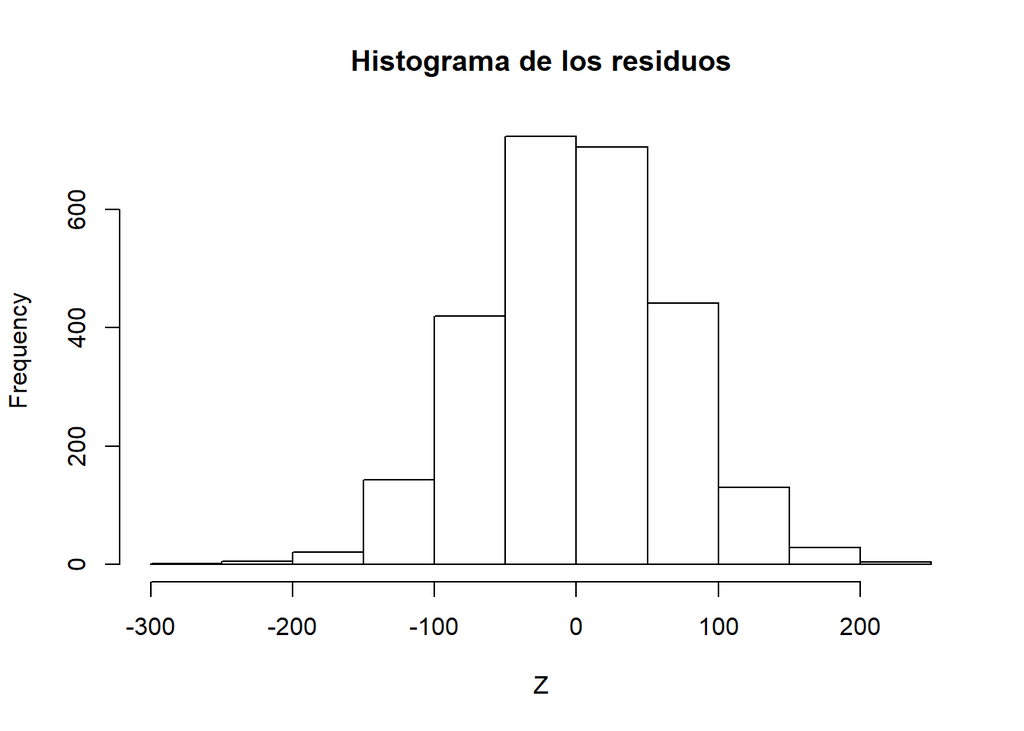

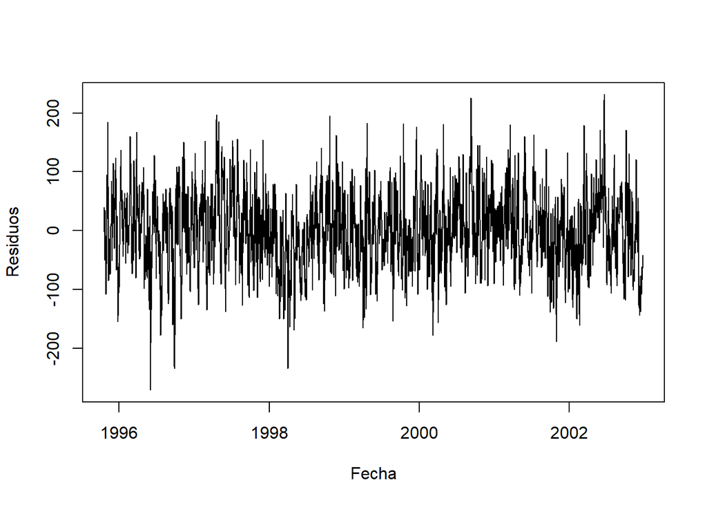

Para ajustar los residuos a un modelo ARIMA debemos chequear si son estacionarios o no. Para ello utilizamos el test ADF el cual plantea como hipótesis alternativa la estacionaridad.

```r
adf.test(Z, k=0)
```

```
##
##  Augmented Dickey-Fuller Test
##
## data:  Z
## Dickey-Fuller = -21.018, Lag order = 0, p-value = 0.01
## alternative hypothesis: stationary
```

El p-value es menor a 0.05 por lo tanto se rechaza la hipótesis nula y concluímos que la serie es estacionaria.

Para obtener una serie con residuos independientes (no correlacionados) aplicamos el comando diff y evaluamos los gráficos de la función de autocorrelación acf para la serie normal y diferenciada con d = 1.

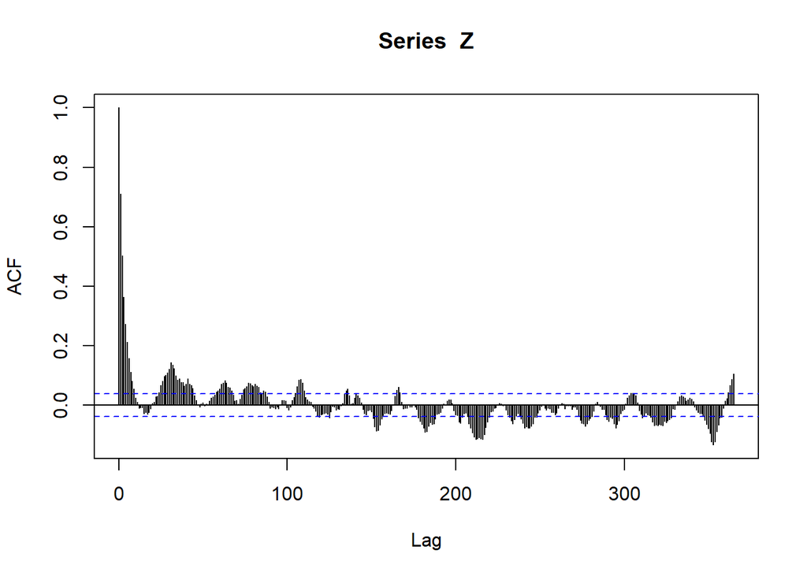

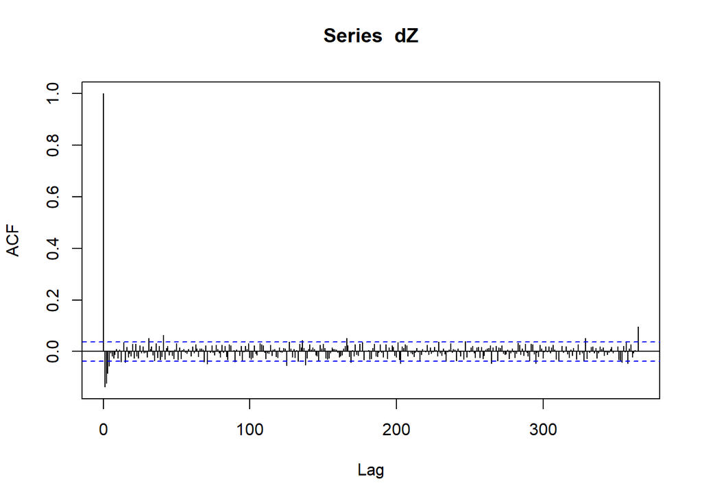

Se observa que las autocorrelaciones disminuyen tomando la diferencia entre los registro con lag = 1. Esto nos indica que tenemos una serie un coeficiente de d=1.

Graficamos la dependencia serial empírica de los residuos de la serie diferenciada.

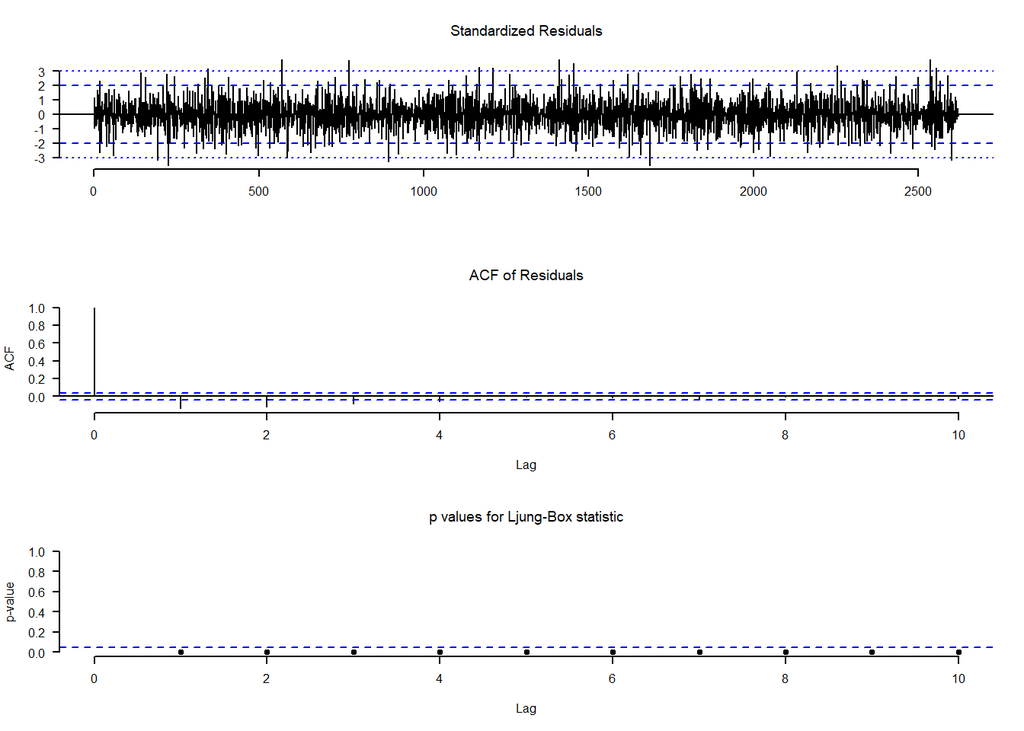

Ahora, simularemos modelos ARIMA (p,1,q) para p y q entre 0 y 4 y guardaremos en una matriz sus valores de AIC.

Matriz de valores de AIC (filas: valores de p, columnas: valores de q)

|  | 0 | 1 | 2 | 3 | 4 |
| --- | --- | --- | --- | --- | --- |
| 0 | 27986.54 | 27916.23 | 27818.46 | 27749.72 | 27658.97 |
| 1 | 27938.81 | 27588.38 | 27589.72 | 27591.48 | 27593.07 |
| 2 | 27886.45 | 27589.74 | 27591.55 | 27593.44 | 27595.39 |
| 3 | 27845.41 | 27591.47 | 27593.42 | 27596.07 | 27597.72 |
| 4 | 27813.28 | 27592.99 | 27600.61 | 27587.92 | 27588.88 |

La matriz sugiere modelos (1,1,1),(4,1,3) y (1,1,2).

Aplicamos la función auto.arima para también evaluar ese modelo.

```r
auto.arima(Z)
```

```
## Series: Z
## ARIMA(1,0,0) with zero mean
##
## Coefficients:
##          ar1
##       0.7112
## s.e.  0.0137
##
## sigma^2 estimated as 2163:  log likelihood=-13793.22
## AIC=27590.44   AICc=27590.45   BIC=27602.19
```

auto.arima(Z) sugiere un modelo (1,0,0).

Evaluamos nuevamente los modelos escogidos esta vez removiendo los coeficientes no significativos obteniendo los siguientes valores de AIC. Es importante notar que el modelo (1,1,1) y el modelo (1,1,2) son idénticos, después de remover el coeficiente de ma2 de este último.

AIC modelos seleccionados

| Modelo | AIC |
| --- | --- |
| 1,1,1 | 27588.38 |
| 4,1,3 | 27593.82 |
| 1,1,2 | 27588.38 |
| 1,0,0 | 27590.44 |